# ECON6120I Assignment 1: Basic programming in R

Da He

18 February 2019

## Simulate data

Consider to simulate data from the following model and estimate the parameters from the simulated data.

$$y_{ij} = 1\{j = argmax_{k = 1,2} \beta {x_k} + \epsilon_{ik}\},$$

where $\epsilon_{ik}$ follows i.i.d. type-I extreme value distribution, $\beta = 0.2$, $x_1 = 0$ and $x_2 = 1$.

1. To simulate data, first make a data frame as follows:

```r
library(tidyverse)
i <- rep(1:1000, each = 2)
k <- rep(1:2, times = 1000)
x <- rep(0:1, times = 1000)
data <- tibble(i, k, x)
list(data)
```

```
## [[1]]
## # A tibble: 2,000 x 3
##        i     k     x
##    <int> <int> <int>
##  1     1     1     0
##  2     1     2     1
##  3     2     1     0
##  4     2     2     1
##  5     3     1     0
##  6     3     2     1
##  7     4     1     0
##  8     4     2     1
##  9     5     1     0
## 10     5     2     1
## # ... with 1,990 more rows
```

2. Second, draw type-I extreme value random variables. Set the seed at 1. You can use `evd` package to draw the variables. You should get exactly the same realization if the seed is correctly set.

```r
# install.packages("evd")
library(evd)
set.seed(1)
e <- rgev(n = 2000)
library(tibble)
data <- add_column(data, e)
list(data)
```

```
## [[1]]
## # A tibble: 2,000 x 4
##        i     k     x       e
##    <int> <int> <int>   <dbl>
##  1     1     1     0  0.281
##  2     1     2     1 -0.167
##  3     2     1     0  1.93
##  4     2     2     1  1.97
##  5     3     1     0  0.830
##  6     3     2     1 -1.06
##  7     4     1     0 -0.207
##  8     4     2     1  0.617
##  9     5     1     0  0.0444
## 10     5     2     1  1.92
## # ... with 1,990 more rows
```

3. Third, compute the latent value of each option to obtain the following data frame:

```r
beta <- 0.2
latent <- beta * x + e
data <- add_column(data, latent)
list(data)
```

```
## [[1]]
## # A tibble: 2,000 x 5
##        i     k     x       e  latent
##    <int> <int> <int>   <dbl>   <dbl>
##  1     1     1     0  0.281   0.281
##  2     1     2     1 -0.167   0.0331
##  3     2     1     0  1.93    1.93
##  4     2     2     1  1.97    2.17
##  5     3     1     0  0.830   0.830
##  6     3     2     1 -1.06   -0.863
##  7     4     1     0 -0.207  -0.207
##  8     4     2     1  0.617   0.817
##  9     5     1     0  0.0444  0.0444
## 10     5     2     1  1.92    2.12
## # ... with 1,990 more rows
```

4. Finally, compute $y$ by comparing the latent values of $k = 1,2$ for each i to obtain the following result:

```r
y <- rep(0, times = 2000)
index <- seq(from = 1, to = 1999, by = 2)
for(j in index){
  if(latent[j] >= latent[j + 1]){y[j] <- 1}
  else{y[j+1] <- 1}
}
data <- add_column(data, y)
list(data)
```

```
## [[1]]
## # A tibble: 2,000 x 6
##        i     k     x       e  latent     y
##    <int> <int> <int>   <dbl>   <dbl> <dbl>
##  1     1     1     0  0.281   0.281      1
##  2     1     2     1 -0.167   0.0331     0
##  3     2     1     0  1.93    1.93       0
##  4     2     2     1  1.97    2.17       1
##  5     3     1     0  0.830   0.830      1
##  6     3     2     1 -1.06   -0.863      0
##  7     4     1     0 -0.207  -0.207      0
##  8     4     2     1  0.617   0.817      1
##  9     5     1     0  0.0444  0.0444     0
## 10     5     2     1  1.92    2.12       1
## # ... with 1,990 more rows
```

## Estimate the parameter

Now you generated simulated data. Suppose you observe $x_k$ and $y_{ik}$ for each $i$ and $k$ and estimate $\beta$ by a maximum likelihood estimator. The likelihood for $i$ to choose $k$ ($y_{ik}=1$) can be shown to be:

$$p_{ik}(\beta) = \frac{exp(\beta x_k)}{exp(\beta x_1) + exp(\beta x_2)}.$$

Then the likelihood of observing $\{y_{ik}\}_{i,k}$ is:

$$L(\beta) = \prod_{i = 1} ^ {1000} p_{i1} (\beta) ^ {y_{i1}}[1 - p_{i1} (\beta)] ^ {1 - y_{i1}},$$

and the log likelihood is:

$$l(\beta) = \prod_{i=1}^{1000} \{y_{i1} log p_{i1} (\beta) + (1 - y_{i1}) log [1 - p_{i1} (\beta)]\}.$$

1. Write a function to compute the livelihood for a given $\beta$ and data and name the function `loglikelihood_A1`.

```r
loglikelihood_A1 <- function(n){
  exp_term <- exp(n * x)
p <- rep(0, times = 2000)
for(j in index){
  p[j] <- exp_term[j] / (exp_term[j] + exp_term[j+1])
  p[j+1] <- exp_term[j+1] / (exp_term[j] + exp_term[j+1])
}
sum <- 0
for (l in 1:2000){
  sum <- sum + y[l] * log(p[l])
  }
return(sum)
}
```

2. Compute the value of log likelihood for $\beta = 0, 0.1, ..., 1$ and plot the result using `ggplot2` packages. You can use `latex2exp` package to use LaTex math symbol in the label:

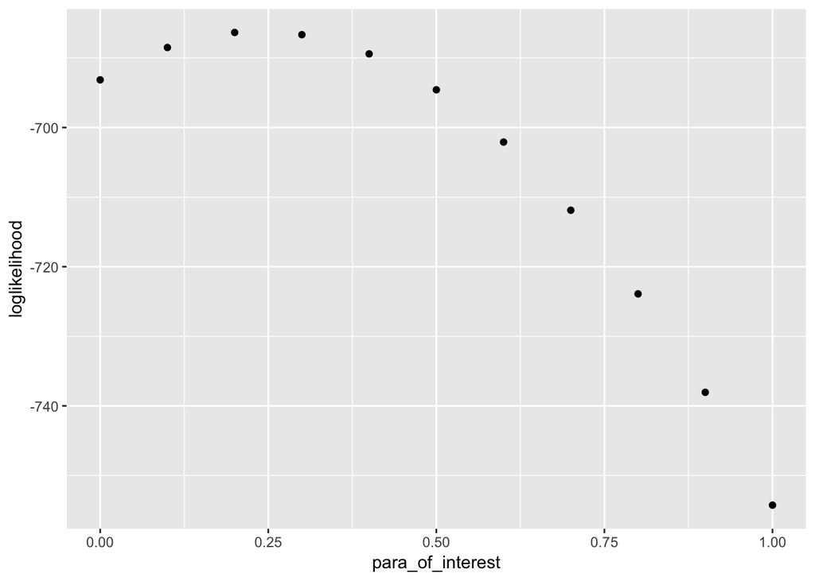

```r
para_of_interest <- c(0, 0.1, 0.2, 0.3, 0.4, 0.5, 0.6, 0.7, 0.8, 0.9, 1)
loglikelihood <- rep(0, times = 11)
for (m in 1:11){loglikelihood[m] <- loglikelihood_A1(n = para_of_interest[m])}
# install.packages("ggplot2")
library(ggplot2)
ggplot2::qplot(para_of_interest, loglikelihood)
```

```r
# install.packages("minqa")
library(minqa)
optim(par = n, fn = loglikelihood_A1, method = c("Brent"), lower = -1, upper = 1)
```

```
## $par
## [1] -1
##
## $value
## [1] -872.2617
##
## $counts
## function gradient
##       NA       NA
##
## $convergence
## [1] 0
##
## $message
## NULL
```